# Popular Websites-Analysis

Deepak Kumar

2017-07-24

This kernel analyses the popular websites across countries based on likes,views per day,child saftey,Trusworthiness among other factors.

```r
setwd("C:/Users/Deepak kumar/Downloads/R/Website Analysis")
getwd()
```

```
## [1] "C:/Users/Deepak kumar/Downloads/R/Website Analysis"
```

```r
library(ggplot2)
library(plotly)
library(stringr)
library(dplyr)
library(ggcorrplot)
library(tidyverse)
```

# Loading Data:

```
##  [1] "Country_Rank"
##  [2] "Website"
##  [3] "Trustworthiness"
##  [4] "Avg_Daily_Visitors"
##  [5] "Child_Safety"
##  [6] "Avg_Daily_Pageviews"
##  [7] "Privacy"
##  [8] "Facebook_likes"
##  [9] "Twitter_mentions"
## [10] "Google_pluses"
## [11] "LinkedIn_mentions"
## [12] "Pinterest_pins"
## [13] "StumbleUpon_views"
## [14] "Status"
## [15] "Traffic_Rank"
```

[output cut: 16 more lines]

```
## Observations: 9,540
## Variables: 31
## $ Country_Rank                             <int> 1, 2, 3, 4, 5, 6, 7, ...
## $ Website                                  <chr> "www.google.com.af", ...
## $ Trustworthiness                          <chr> "Excellent", "Excelle...
## $ Avg_Daily_Visitors                       <chr> "N/A", "515 007 350",...
## $ Child_Safety                             <chr> "Excellent", "Excelle...
## $ Avg_Daily_Pageviews                      <chr> "N/A", "4 192 159 833...
## $ Privacy                                  <chr> "Excellent", "Excelle...
## $ Facebook_likes                           <chr> "9", "94.2K", "13.5K"...
## $ Twitter_mentions                         <chr> "1", "11.2K", "16.5K"...
## $ Google_pluses                            <chr> "37", "11.7M", "19.3M...
## $ LinkedIn_mentions                        <chr> "7", "1.67K", "60K", ...
## $ Pinterest_pins                           <chr> "-", "10.8K", "47", "...
## $ StumbleUpon_views                        <chr> "7", "246K", "329K", ...
```

[output cut: 18 more lines]

```
## [1] 9540   31
```

## Data Cleaning:

There are 9540 observations and 31 columns.There are spaces inbetween the numbers.Lets convert them into num without spaces.

```r
web$Avg_Daily_Visitors=as.factor(str_replace_all(web$Avg_Daily_Visitors,fixed(" "),""))
web$Avg_Daily_Visitors=as.factor(str_replace_all(web$Avg_Daily_Visitors,"NA"," "))
web$Avg_Daily_Pageviews=as.factor(str_replace_all(web$Avg_Daily_Pageviews,fixed(" "),""))
web$Avg_Daily_Pageviews=as.factor(str_replace_all(web$Avg_Daily_Pageviews,"NA"," "))
web$Avg_Daily_Visitors=as.double(web$Avg_Daily_Visitors)
web$Avg_Daily_Pageviews=as.double(web$Avg_Daily_Pageviews)
glimpse(web)
```

```
## Observations: 9,540
## Variables: 31
## $ Country_Rank                             <int> 1, 2, 3, 4, 5, 6, 7, ...
## $ Website                                  <chr> "www.google.com.af", ...
## $ Trustworthiness                          <chr> "Excellent", "Excelle...
## $ Avg_Daily_Visitors                       <dbl> 3057, 2189, 2172, 136...
## $ Child_Safety                             <chr> "Excellent", "Excelle...
## $ Avg_Daily_Pageviews                      <dbl> 1851, 1264, 800, 47, ...
## $ Privacy                                  <chr> "Excellent", "Excelle...
## $ Facebook_likes                           <chr> "9", "94.2K", "13.5K"...
## $ Twitter_mentions                         <chr> "1", "11.2K", "16.5K"...
## $ Google_pluses                            <chr> "37", "11.7M", "19.3M...
## $ LinkedIn_mentions                        <chr> "7", "1.67K", "60K", ...
## $ Pinterest_pins                           <chr> "-", "10.8K", "47", "...
## $ StumbleUpon_views                        <chr> "7", "246K", "329K", ...
```

[output cut: 18 more lines]

# Overview:

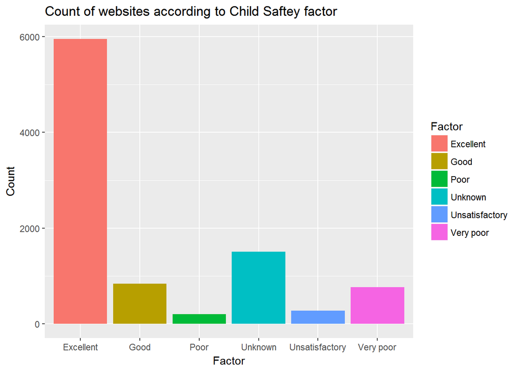

```r
temp=data.frame(table(web$Child_Safety))
colnames(temp)=c("Factor","Count")
ggplot(temp,aes(x=factor(Factor,levels=Factor),y=Count,fill=Factor))+geom_bar(stat="identity")+labs(x="Factor",y="Count")+ggtitle("Count of websites according to Child Saftey factor")
```

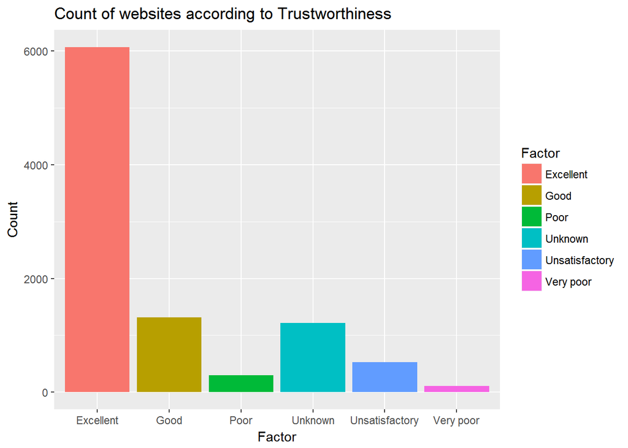

```r
temp=data.frame(table(web$Trustworthiness))
colnames(temp)=c("Factor","Count")
ggplot(temp,aes(x=factor(Factor,levels=Factor),y=Count,fill=Factor))+geom_bar(stat="identity")+labs(x="Factor",y="Count")+ggtitle("Count of websites according to Trustworthiness")
```

[figure not shown]

```r
temp=data.frame(table(web$Privacy))
colnames(temp)=c("Factor","Count")
ggplot(temp,aes(x=factor(Factor,levels=Factor),y=Count,fill=Factor))+geom_bar(stat="identity")+labs(x="Factor",y="Count")+ggtitle("Count of websites according to Trustworthiness")
```

# Which country tops web usage?

Based on avg number of visitors to a website, lts rank the top 20 countries to understand which country visits the top 50 popular websites.

```r
temp=web %>% group_by(country) %>% summarise(count=sum(Avg_Daily_Visitors)) %>% arrange(desc(count))
temp%>% head(20) %>% plot_ly(x=~factor(country,level=country),y=~count,type="bar")%>% layout(title="Avg Visits by Country",xaxis=list(title="Country"),yaxis=list(title="Avg"))
```

[interactive chart not shown]

## Website Analysis:

> Which website has been consistently rated within number 10 in all countries?

```r
length(unique(web$country))
```

```
## [1] 191
```

```r
temp= web %>% filter(Country_Rank %in% 1:10)  %>% group_by(Website) %>% summarise(count=n()) %>% arrange(desc(count))
temp %>% head(10) %>% plot_ly(x=~factor(Website,level=Website),y=~count,color="Website",type="bar",mode="markers") %>% layout(xaxis=list(title="Website"),yaxis=list(title="Count of Countries"),title="Top 10 Most visited Website")
```

[interactive chart not shown]

- It isnt surprising going by the list that `google.com` tops in 190 out of 191 countries considered for study followed by `youtube.com` and `facebook.com`.Let us see which country has not ranked `google,youtube and facebook` under top 10.

```r
web %>% select(Website,country,Country_Rank) %>% filter(Website=="www.google.com" & (Country_Rank %in% 11:50))
```

```
##          Website country Country_Rank
## 1 www.google.com   China           11
```

```r
web %>% select(Website,country,Country_Rank) %>% filter(Website=="www.youtube.com" & (Country_Rank %in% 11:50))
```

```
##           Website country Country_Rank
## 1 www.youtube.com   China           12
```

```r
web %>% select(Website,country,Country_Rank) %>% filter(Website=="www.facebook.com" & (Country_Rank %in% 11:50))
```

```
##            Website    country Country_Rank
## 1 www.facebook.com    Belarus           26
## 2 www.facebook.com   Ethiopia           16
## 3 www.facebook.com Kazakhstan           27
## 4 www.facebook.com Kyrgyzstan           20
## 5 www.facebook.com    Moldova           12
## 6 www.facebook.com     Russia           20
## 7 www.facebook.com Tajikistan           30
## 8 www.facebook.com    Ukraine           11
## 9 www.facebook.com Uzbekistan           18
```

Let us understand which website is rated in most countries as having excellent child saftey & trustworthiness?

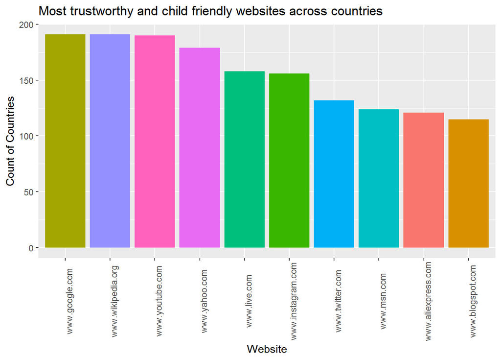

```r
temp= web %>% filter(Trustworthiness=="Excellent" & Child_Safety=="Excellent") %>% group_by(Website) %>% summarise(count=n()) %>% arrange(desc(count))
temp %>% head(10) %>%  ggplot(aes(x=factor(Website,levels=Website),y=count,fill=Website))+geom_bar(stat="identity")+theme(axis.text.x=element_text(angle=90),legend.position ="None")+labs(x="Website",y="Count of Countries")+ggtitle("Most trustworthy and child friendly websites across countries")
```

# Which country tops the list with websites under 50 ranks that have excellent trustworthiness,child saftey and privacy ratings?

```r
temp= web%>% filter(Trustworthiness=="Excellent" & Child_Safety=="Excellent" & Privacy == "Excellent") %>% group_by(country) %>% summarise(count=n()) %>% arrange(desc(count))
q=temp%>% head(20) %>% ggplot(aes(x=factor(country,levels=country),y=count,fill=country))+geom_bar(stat="identity")+theme(axis.text.x=element_text(angle=90),legend.position ="None")+labs(x="Country",y="Count of Countries")+ggtitle("Countries with excellent rating of websites")
ggplotly(q)
```

```
## We recommend that you use the dev version of ggplot2 with `ggplotly()`
## Install it with: `devtools::install_github('hadley/ggplot2')`
```

[interactive chart not shown]

# Which website dominates the bottom rankings in most of the countries?

In a simiar manner as we did the top 10 rated websites across countries,we do this for bottom 10 websites to understand the pattern.

```r
temp= web %>% filter(Country_Rank %in% 40:50) %>% group_by(Website) %>% summarise(count=n()) %>% arrange(desc(count))
temp %>% head(10) %>% plot_ly(x=~factor(Website,level=Website),y=~count,color="Website",type="bar",mode="markers") %>% layout(xaxis=list(title="Website"),yaxis=list(title="Count of Countries"))
```

[interactive chart not shown]

The ratings provides a surprising insight that giants like microsoft,amazon,stackoverflow and linkedin has rating within 40-50 ranks in most of the countries.